# R Notebook: TCGA_RNAseq_analysis

This notebook contains my code and workflow for RNA-seq analysis on TCGA-LGG project which is brain lower grade glioma project containing 516 cases for transcriptome profiling.

First, I am loading following packages required for analysis:

```r
# Load packages
library("TCGAbiolinks")
library("limma")
library("edgeR")
library("glmnet")
library("factoextra")
library("FactoMineR")
library("caret")
library("SummarizedExperiment")
library("gplots")
library("survival")
library("survminer")
library("RColorBrewer")
library("gProfileR")
library("genefilter")
```

Let’s look at the projects available on GDC:

```r
GDCprojects = getGDCprojects()

head(GDCprojects[c("project_id", "name")])
```

|  | project_id | name |
| --- | --- | --- |
| 1 | GENIE-MSK | AACR Project GENIE - Contributed by Memorial Sloan Kettering Cancer Center |
| 2 | TCGA-UCEC | Uterine Corpus Endometrial Carcinoma |
| 3 | TCGA-LGG | Brain Lower Grade Glioma |
| 4 | TCGA-SARC | Sarcoma |
| 5 | TCGA-PAAD | Pancreatic Adenocarcinoma |
| 6 | TCGA-ESCA | Esophageal Carcinoma |

I have picked brain lower grade glioma project which has a project id “TCGA-LGG”. GDCquery() function from TCGAbiolinks package allows me to look at some of the information available for the TCGA-LGG project available in the TCGA database. I am going to look at the RNAseq data for this project

```r
query_lgg <- GDCquery(project = "TCGA-LGG", data.category = "Transcriptome Profiling", experimental.strategy = "RNA-Seq", workflow.type = "HTSeq - Counts")
```

```
--------------------------------------
o GDCquery: Searching in GDC database
--------------------------------------
Genome of reference: hg38
--------------------------------------------
oo Accessing GDC. This might take a while...
--------------------------------------------
ooo Project: TCGA-LGG
```

getResults() function would give me the counts data in the form of a table which will be useful for further analysis

```r
lgg_results <- getResults(query_lgg)
```

```r
colnames(lgg_results)
```

```
 [1] "id"                        "data_format"
 [3] "cases"                     "access"
 [5] "file_name"                 "submitter_id"
 [7] "data_category"             "type"
 [9] "created_datetime"          "file_size"
[11] "updated_datetime"          "md5sum"
[13] "file_id"                   "data_type"
[15] "state"                     "experimental_strategy"
[17] "version"                   "data_release"
[19] "project"                   "analysis_id"
[21] "analysis_state"            "analysis_submitter_id"
[23] "analysis_workflow_link"    "analysis_workflow_type"
[25] "analysis_workflow_version" "sample_type"
[27] "is_ffpe"                   "cases.submitter_id"
[29] "sample.submitter_id"
```

```r
head(lgg_results$sample_type) #looking at the type of tumor
```

```
[1] "Primary Tumor" "Primary Tumor" "Primary Tumor" "Primary Tumor"
[5] "Primary Tumor" "Primary Tumor"
```

```r
#subset samples with sample_type entered as "Primary Tumor"
primary_tumor_res <- lgg_results[lgg_results$sample_type == "Primary Tumor",]
#subset samples which are not entered as "Primary Tumor"
nonprimary_tumor_res <- lgg_results[lgg_results$sample_type != "Primary Tumor",]
nonprimary_tumor_res$sample_type    #Looking at the sample_type in non-primary tumor
```

```
 [1] "Recurrent Tumor" "Recurrent Tumor" "Recurrent Tumor"
 [4] "Recurrent Tumor" "Recurrent Tumor" "Recurrent Tumor"
 [7] "Recurrent Tumor" "Recurrent Tumor" "Recurrent Tumor"
[10] "Recurrent Tumor" "Recurrent Tumor" "Recurrent Tumor"
[13] "Recurrent Tumor" "Recurrent Tumor" "Recurrent Tumor"
[16] "Recurrent Tumor" "Recurrent Tumor" "Recurrent Tumor"
```

We can see above that there are 18 samples with sample_type given as “Recurrent Tumor” and remaining 511 samples have sample_type given as “Primary Tumor”. I am removing samples with “Recurrent tumor” as sample_type. Redoing the query:

```r
query_lgg <- GDCquery(project = "TCGA-LGG", data.category = "Transcriptome Profiling", experimental.strategy = "RNA-Seq", workflow.type = "HTSeq - Counts", sample.type = "Primary Tumor")
```

```
--------------------------------------
o GDCquery: Searching in GDC database
--------------------------------------
Genome of reference: hg38
--------------------------------------------
oo Accessing GDC. This might take a while...
--------------------------------------------
ooo Project: TCGA-LGG
--------------------
oo Filtering results
--------------------
ooo By experimental.strategy
ooo By workflow.type
ooo By sample.type
----------------
oo Checking data
----------------
ooo Check if there are duplicated cases
ooo Check if there results for the query
-------------------
o Preparing output
-------------------
```

Downloading files specified in the query above:

```r
GDCdownload(query = query_lgg)
```

```
Downloading data for project TCGA-LGG
Of the 511 files for download 511 already exist.
All samples have been already downloaded
```

Loading the RNASeq data into R with GDCprepare() function:

```r
lgg_data <- GDCprepare(query_lgg)
```

[output not shown]

[output cut: 457 more lines]

[output not shown]

```
Starting to add information to samples
 => Add clinical information to samples
 => Adding TCGA molecular information from marker papers
 => Information will have prefix 'paper_'
lgg subtype information from:doi:10.1016/j.cell.2015.12.028
From the 60483 genes we couldn't map 3881
```

```r
dim(lgg_data)     #dim() function gives the dimensions of lgg_data counts table
```

```
[1] 56602   511
```

```r
data.class(lgg_data)  #the lgg_data is loaded as a Ranged summarized experiment as seen below
```

```
[1] "RangedSummarizedExperiment"
```

The data is loaded in R as Ranged summarized experiment object. Therefore, we will use three functions, colData(), rowData(), and assay(), to access data from this object. colData() function can access the clinical data table associated with the samples.

```r
colnames(colData(lgg_data))
```

```
  [1] "barcode"
  [2] "patient"
  [3] "sample"
  [4] "shortLetterCode"
  [5] "definition"
  [6] "sample_submitter_id"
  [7] "sample_type_id"
  [8] "sample_id"
  [9] "sample_type"
 [10] "days_to_collection"
 [11] "state"
 [12] "initial_weight"
 [13] "intermediate_dimension"
 [14] "pathology_report_uuid"
 [15] "submitter_id"
```

[output cut: 94 more lines]

assay() function is used to access counts data for the summarized experiment object. Rows are gene ids and columns are sample names in the counts table.

```r
head(assay(lgg_data)[,1:5])       #counts for first 6 genes and first 5 samples
```

```
                TCGA-EZ-7264-01A-11R-2027-07
ENSG00000000003                         2407
ENSG00000000005                            3
ENSG00000000419                         1430
ENSG00000000457                         1364
ENSG00000000460                          394
ENSG00000000938                          319
                TCGA-QH-A870-01A-11R-A36H-07
ENSG00000000003                         6152
ENSG00000000005                            1
ENSG00000000419                         1003
ENSG00000000457                          715
ENSG00000000460                          248
ENSG00000000938                          169
                TCGA-HT-A74O-01A-11R-A32Q-07
ENSG00000000003                         2417
ENSG00000000005                            0
ENSG00000000419                          963
ENSG00000000457                          385
ENSG00000000460                          147
ENSG00000000938                          467
                TCGA-HT-7469-01A-11R-2256-07
ENSG00000000003                        11744
ENSG00000000005                          108
ENSG00000000419                         1587
ENSG00000000457                         1612
ENSG00000000460                          758
ENSG00000000938                          304
                TCGA-DU-7292-01A-11R-2027-07
ENSG00000000003                         2878
ENSG00000000005                            9
ENSG00000000419                         1055
ENSG00000000457                          722
ENSG00000000460                          257
ENSG00000000938                          360
```

Saving RNASeq data as ‘.RDS’ file which can be loaded anytime using readRDS() function without having to run the whole notebook again

```r
saveRDS(object = lgg_data,
        file = "lgg_data.RDS",
        compress = FALSE)
```

Let’s load the lgg_data.RDS:

```r
lgg_data <- readRDS(file = "lgg_data.RDS")
```

I am going to look the summaries of some columns from colData to get a better understanding. I will use table() function for that:

```r
table(lgg_data@colData$gender)
```

```
female   male
   228    282
```

There are a total of 510 patients with a gender specified, and 1 patient whose gender is not specified, we will remove that sample from counts table:

```r
complete.cases(lgg_data@colData$gender)
```

```
  [1]  TRUE  TRUE  TRUE  TRUE  TRUE  TRUE  TRUE  TRUE
  [9]  TRUE  TRUE  TRUE  TRUE  TRUE  TRUE  TRUE  TRUE
 [17]  TRUE  TRUE  TRUE  TRUE  TRUE  TRUE  TRUE  TRUE
 [25]  TRUE  TRUE  TRUE  TRUE  TRUE  TRUE  TRUE  TRUE
 [33]  TRUE  TRUE  TRUE  TRUE  TRUE  TRUE  TRUE  TRUE
 [41]  TRUE  TRUE  TRUE  TRUE  TRUE  TRUE  TRUE  TRUE
 [49]  TRUE  TRUE  TRUE  TRUE  TRUE  TRUE  TRUE  TRUE
 [57]  TRUE  TRUE  TRUE  TRUE  TRUE  TRUE  TRUE  TRUE
 [65]  TRUE  TRUE  TRUE  TRUE  TRUE  TRUE  TRUE  TRUE
 [73]  TRUE  TRUE  TRUE  TRUE  TRUE  TRUE  TRUE  TRUE
 [81]  TRUE  TRUE  TRUE  TRUE  TRUE  TRUE  TRUE  TRUE
 [89]  TRUE  TRUE  TRUE  TRUE  TRUE  TRUE  TRUE  TRUE
 [97]  TRUE  TRUE  TRUE  TRUE  TRUE  TRUE  TRUE  TRUE
[105]  TRUE  TRUE  TRUE  TRUE  TRUE  TRUE  TRUE  TRUE
[113]  TRUE  TRUE  TRUE  TRUE  TRUE  TRUE  TRUE  TRUE
```

[output cut: 49 more lines]

```r
phenotype_data[366, c("patient", "gender")]
```

```
DataFrame with 1 row and 2 columns
                                  patient
                              <character>
TCGA-R8-A6YH-01A-21R-A32Q-07 TCGA-R8-A6YH
                                  gender
                             <character>
TCGA-R8-A6YH-01A-21R-A32Q-07          NA
```

```r
NA_removed_pheno <- colData(lgg_data)[-366,]
NA_removed_counts <- subset(assay(lgg_data), select = -366)       #removing 366th column which corresponds to the sample with NA as
```

```r
dim(NA_removed_pheno)
```

```
[1] 510 109
```

```r
dim(NA_removed_counts)
```

```
[1] 56602   510
```

```r
table(lgg_data@colData$paper_Age..years.at.diagnosis.)
```

```
14 17 18 19 20 21 22 23 24 25 26 27 28 29 30 31 32 33 34 35 36 37 38
 1  1  1  1  5  4  3  5  6  7  8  6  7 13 18 16 10 17 13 14 12 12 18
39 40 41 42 43 44 45 46 47 48 49 50 51 52 53 54 55 56 57 58 59 60 61
13 11 13  7 13 10  6  5 10 12  7  7  9 11  9 11  5  7  7  8 10  7  7
62 63 64 65 66 67 68 69 70 71 73 74 75 87
 9  4  4  3  7  4  1  3  5  1  3  4  1  1
```

```r
table(lgg_data@colData$paper_Vital.status..1.dead.)
```

```
  0   1
373  80
```

```r
table(lgg_data@colData$tumor_stage)
```

```
not reported
         510
```

```r
table(lgg_data@colData$race)
```

```
american indian or alaska native                            asian
                               1                                8
       black or african american                     not reported
                              21                               10
                           white
                             470
```

```r
table(lgg_data@colData$definition)
```

```
Primary solid Tumor
                511
```

Differential Expression analysis:

I will be looking at whether there are differentially expressed genes in male vs female brain glioma patients. First, I will normalize the counts data in order to handle batch effects:

```r
phenotype_data <- colData(lgg_data)
gender_factor <- factor(phenotype_data$gender) #converting gender into a factor variable in order to use it for limma package
gender_factor <- relevel(gender_factor, ref = "female") #setting "female" as the reference level
```

```r
design_mat <- model.matrix(~gender_factor)  #creating a design matrix to be used for DE analysis
head(design_mat)
```

```
  (Intercept) gender_factormale
1           1                 0
2           1                 0
3           1                 1
4           1                 1
5           1                 1
6           1                 1
```

```r
dge_gender <- DGEList(counts = NA_removed_counts, samples = NA_removed_pheno, genes = as.data.frame(rowData(lgg_data)))  #creating a DGEList object from lgg_data, facilitates filtering

keep_genes <- filterByExpr.default(dge_gender, design_mat)   #keeps genes which have read counts above 10 (default)
dge_gender <- dge_gender[keep_genes, , keep.lib.sizes = FALSE]   #filtering the DGEList object
rm(keep_genes)
dim(dge_gender)
```

```
[1] 22140   510
```

I am using Trimmed mean of M-values (TMM) method for data normalization. And I am using VOOM method to convert the data to have a similar variance as arrays (must do this for limma)

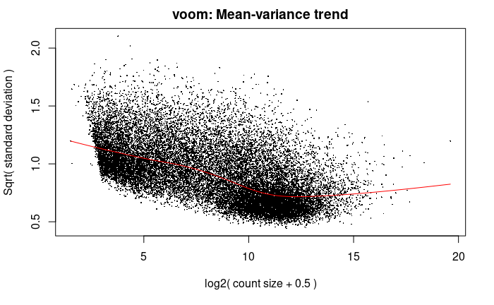

```r
dge_gender = calcNormFactors(dge_gender,method="TMM")
v_gender = voom(dge_gender,design_mat,plot=TRUE)
```

```r
linear_mods <- lmFit(v_gender, design_mat)
linear_mods <- eBayes(linear_mods)
```

```r
DE_genes <- topTable(linear_mods, coef = 1, sort.by ="p")
print(DE_genes)
```

|  | ensembl_gene_id | external_gene_name | original_ensembl_gene_id | logFC | AveExpr | t | P.Value | adj.P.Val | B |
| --- | --- | --- | --- | --- | --- | --- | --- | --- | --- |
| ENSG00000000003 | ENSG00000000003 | TSPAN6 | ENSG00000000003.13 | 5.840246 | 5.871891 | 138.11530 | 0 | 0 | 924.1138 |
| ENSG00000000419 | ENSG00000000419 | DPM1 | ENSG00000000419.11 | 4.369525 | 4.357784 | 246.57583 | 0 | 0 | 1214.9265 |
| ENSG00000000457 | ENSG00000000457 | SCYL3 | ENSG00000000457.12 | 3.780946 | 3.761106 | 226.98293 | 0 | 0 | 1172.8860 |
| ENSG00000001084 | ENSG00000001084 | GCLC | ENSG00000001084.9 | 6.295308 | 6.383120 | 138.35504 | 0 | 0 | 924.9783 |
| ENSG00000001167 | ENSG00000001167 | NFYA | ENSG00000001167.13 | 4.962754 | 4.975336 | 160.41659 | 0 | 0 | 998.8703 |
| ENSG00000001497 | ENSG00000001497 | LAS1L | ENSG00000001497.15 | 5.848423 | 5.840975 | 208.02955 | 0 | 0 | 1129.6004 |
| ENSG00000001629 | ENSG00000001629 | ANKIB1 | ENSG00000001629.8 | 7.046328 | 7.108753 | 204.81032 | 0 | 0 | 1121.7553 |
| ENSG00000001631 | ENSG00000001631 | KRIT1 | ENSG00000001631.13 | 5.251166 | 5.243810 | 189.91205 | 0 | 0 | 1083.6507 |
| ENSG00000002016 | ENSG00000002016 | RAD52 | ENSG00000002016.15 | 3.753892 | 3.802536 | 95.46705 | 0 | 0 | 742.4112 |
| ENSG00000002330 | ENSG00000002330 | BAD | ENSG00000002330.12 | 5.699296 | 5.700214 | 161.60116 | 0 | 0 | 1002.5938 |